# Sentiment analysis of the spread of hate in tweets using RNN [Reproducible Research]

## 1. Understanding the Problem Statement

Twitter is one of the biggest and most popular social networks with around 300 million users, 40% of which are active on the platform multiple times per day. Hence, it’s understandable the need to monitor the sentiment of the users, especially if it can help stop the spread of hateful and damaging massages.

The goal of our project is to reproduce the original project and to replicate the results using the dataset described below, with the aim of building a robust model for predicting hate tweets. The model is based on Recurrent Neural Networks (RNNs), with the implementation and evaluation of different layers such as LSTM, GRU. Furthermore, we used pretrained word vectors from GloVe model trained with tweets, which is loaded in our model in an Embedding layer.

## 2. About the dataset

The data used was found on Kaggle:

https://www.kaggle.com/datasets/ashwiniyer176/toxic-tweets-dataset

```
id - ID assigned to each tweet
toxicity - 1 if the tweeter is considered hateful and 0 non-hateful
tweet - string containing tweet’s text.
```

Additionally, in our repository it is possible to find a diferent test dataset with 17197 unlabeled tweets which we will try to label in the end using our final and improved model (this last dataset comes from the original project).

## 3. Import Libraries

```python
# Import modules

import numpy
import numpy as np
from numpy.random import seed

import pandas as pd
import matplotlib.pyplot as plt
import re
import spacy
import inspect
import tensorflow
from wordcloud import WordCloud, STOPWORDS
from nltk import FreqDist

from sklearn.model_selection import train_test_split
from sklearn.metrics import confusion_matrix

from keras.preprocessing.text import Tokenizer
from keras_preprocessing.sequence import pad_sequences
from keras.models import Sequential
from keras.layers import Dense
from keras.layers import LSTM
from keras.layers import GRU
from keras.layers import Dropout
from keras.layers import Conv1D
from keras.layers import MaxPooling1D
from keras.layers import Embedding
from keras.utils.np_utils import to_categorical
from keras.initializers import Constant
```

## 4. Read and Inspect the Data

```python
data_columns = ["ids","label","tweet"]
tweets= pd.read_csv('training.csv', names=data_columns)[1:]
tweets.head()
```

|  | ids | label | tweet |
| --- | --- | --- | --- |
| 1 | 0.0 | 0 | @user when a father is dysfunctional and is s... |
| 2 | 1.0 | 0 | @user @user thanks for #lyft credit i can't us... |
| 3 | 2.0 | 0 | bihday your majesty |
| 4 | 3.0 | 0 | #model i love u take with u all the time in ... |
| 5 | 4.0 | 0 | factsguide: society now #motivation |

```python
#tweets=tweets.sample(frac = 0.3)
```

```python
tweets["label"].replace({"0": 0, "1": 1}, inplace=True)
```

```python
np.unique(tweets.label)
```

```
array([0, 1])
```

```python
print("Hatred labeled: {}\nNon-hatred labeled: {}".format(
    (tweets.label == 1).sum(),
    (tweets.label == 0).sum()
))
```

```
Hatred labeled: 24153
Non-hatred labeled: 32592
```

## 5. Text Cleaning and Preprocessing

```python
# remove URL's and @users
tweets['clean_tweet'] = tweets['tweet'].apply(lambda x: re.sub(r'http\S+', '', x))
tweets['clean_tweet'] = tweets['clean_tweet'].apply(lambda x: re.sub(r'&#\S+', '', x))
tweets['clean_tweet'] = tweets['clean_tweet'].apply(lambda x: re.sub('@[a-zA-Z0-9_]+', '', x))
```

```python
#Removing hashtags and creating hashtags column
hashtags = tweets['clean_tweet'].str.extractall('#(?P<hashtag>[a-zA-Z0-9_]+)').reset_index().groupby('level_0').agg(lambda x: ' '.join(x.values))
tweets.loc[:, 'hashtags'] = hashtags['hashtag']
tweets['hashtags'].fillna('', inplace=True)
```

```python
# remove punctuation marks
punctuation = '!"#$%&()*+-/:;<=>?@[\\]^_`{|}~'

tweets['clean_tweet'] = tweets['clean_tweet'].apply(lambda x: ''.join(ch for ch in x if ch not in set(punctuation)))

# convert text to lowercase
tweets['clean_tweet'] = tweets['clean_tweet'].str.lower()

# remove numbers
tweets['clean_tweet'] = tweets['clean_tweet'].str.replace("[0-9]", " ")

# remove whitespaces
tweets['clean_tweet'] = tweets['clean_tweet'].apply(lambda x:' '.join(x.split()))
```

```python
#Lemmatizing tweets

#!pip3 install -U spacy
#!python3 -m spacy download en_core_web_sm

nlp = spacy.load('en_core_web_sm', disable=['parser', 'ner'])

# function to lemmatize text
def lemmatization(texts):
    output = []
    for i in texts:
        s = [token.lemma_ for token in nlp(i)]
        output.append(' '.join(s))
    return output
```

```python
tweets['clean_tweet'] = lemmatization(tweets['clean_tweet'])
```

```python
#Removing whatever non-character rest that could remain in the tweets

tweets['clean_tweet2'] = tweets.clean_tweet.str.replace('[^a-zA-Z]', ' ')
#tweets['lwords'] = tweets['clean_tweet2'].apply(lambda x: x.split())
```

```python
pd.set_option("display.max_colwidth", -1)
```

```python
tweets.sample(50)
```

|  | ids | label | tweet | clean_tweet | hashtags | clean_tweet2 |
| --- | --- | --- | --- | --- | --- | --- |
| 49390 | 49389.0 | 1 | RT @StevStiffler: If her bio says "Only God can judge me" she's a hoe. | rt if her bio say only god can judge I she be a hoe . |  | rt if her bio say only god can judge I she be a hoe |
| 31667 | 31666.0 | 0 | @user and the industry is completely able to develope thousands of #recyclable materials. the #change is #always in our #hands | and the industry be completely able to develope thousand of recyclable material . the change be always in our hand | recyclable change always hands | and the industry be completely able to develope thousand of recyclable material the change be always in our hand |
| 27417 | 27416.0 | 0 | â #new zealand current account - gdp ratio meets forecasts (-3%) in 1q #blog #silver #gold #forex | â new zealand current account gdp ratio meet forecast in q blog silver gold forex | new blog silver gold forex | new zealand current account gdp ratio meet forecast in q blog silver gold forex |
| 21650 | 21649.0 | 1 | @user #allahsoil marx's revolution occurredâjust not how he expected it to. â¦ â¦ #teambtsâ¦ | allahsoil marx 's revolution occurredâjust not how he expect it to . â ¦ â ¦ teambtsâ ¦ | allahsoil teambts | allahsoil marx s revolution occurred just not how he expect it to teambts |
| 38098 | 38097.0 | 1 | @iStandy is he chunky? | be he chunky |  | be he chunky |
| 23398 | 23397.0 | 0 | "poem " by @user on @user | poem by on |  | poem by on |
| 53367 | 53366.0 | 1 | That long hair doesn't cover up your redneck | that long hair do not cover up your redneck |  | that long hair do not cover up your redneck |
| 13841 | 13840.0 | 0 | @user bihday haryana clpleader | bihday haryana clpleader |  | bihday haryana clpleader |
| 15961 | 15960.0 | 0 | played it... loved it. #horizonzerodawn #e3 #e32016 | play it ... love it . horizonzerodawn e e | horizonzerodawn e3 e32016 | play it love it horizonzerodawn e e |
| 41572 | 41571.0 | 1 | Ha.. Who can get the pussy quicker these days | ha .. who can get the pussy quick these day |  | ha who can get the pussy quick these day |
| 37736 | 37735.0 | 1 | @cristiannt_ bitch I back shit up fuck nigga | bitch I back shit up fuck nigga |  | bitch I back shit up fuck nigga |
| 47049 | 47048.0 | 1 | RT @EMAdair225: Illegals bringing diseases across border. Contagious patients separated from others by yellow tape... pregnant teens http:/&#8230; | rt illegal bring disease across border . contagious patient separate from other by yellow tape ... pregnant teen |  | rt illegal bring disease across border contagious patient separate from other by yellow tape pregnant teen |
| 55592 | 55591.0 | 1 | bitch i will cut you | bitch I will cut you |  | bitch I will cut you |
| 9547 | 9546.0 | 0 | time to go back ! travelling to hogwas ...oh i mean travelling to london :p #mozlondon | time to go back travel to hogwas ... oh I mean travel to london p mozlondon | mozlondon | time to go back travel to hogwas oh I mean travel to london p mozlondon |
| 8785 | 8784.0 | 0 | hey guys got some big news i am going to be sharing with you guys tomorrow!!! ð¥ð¥ðð¾ð¥ð¥ #edm | hey guy get some big news I be go to be share with you guy tomorrow ð¥ð¥ðð¾ð¥ð¥ edm | edm | hey guy get some big news I be go to be share with you guy tomorrow edm |
| 45500 | 45499.0 | 1 | Oh it was multiple DNA on ol girl man they ran a train on that hoe &#128514;&#128514;&#128514; | oh it be multiple dna on ol girl man they run a train on that hoe |  | oh it be multiple dna on ol girl man they run a train on that hoe |
| 4033 | 4032.0 | 0 | @user i finally found a way how to delete old tweets! you might find it useful as well: #deletetweets | I finally find a way how to delete old tweet you might find it useful as well deletetweet | deletetweets | I finally find a way how to delete old tweet you might find it useful as well deletetweet |
| 25507 | 25506.0 | 0 | retweeted intentional insights (@user 12 #science based tips on how to maintain and lasting... | retweete intentional insight science base tip on how to maintain and last ... | science | retweete intentional insight science base tip on how to maintain and last |
| 36343 | 36342.0 | 1 | @PacTha_Mac imma shoot that bitch | imma shoot that bitch |  | imma shoot that bitch |
| 14705 | 14704.0 | 0 | #bridetobe #wedding2017 #weddingcountdown begins ....#hat #design ... conjured | bridetobe wedding weddingcountdown begin .... hat design ... conjure | bridetobe wedding2017 weddingcountdown hat design | bridetobe wedding weddingcountdown begin hat design conjure |
| 32272 | 32271.0 | 1 | "@ambitiousBree: @_1nonlykeisha u see the damn phone ringing? &#128547;&#128530;&#128542;" when you married bitches makes demands!!!! You haven't called me | u see the damn phone ringing when you marry bitch make demand you have not call I |  | u see the damn phone ringing when you marry bitch make demand you have not call I |
| 40579 | 40578.0 | 1 | Damn Joe Buck just making it sound like Greinke was trash when he played for the Royals. Chill out Joe. | damn joe buck just make it sound like greinke be trash when he play for the royal . chill out joe . |  | damn joe buck just make it sound like greinke be trash when he play for the royal chill out joe |
| 46127 | 46126.0 | 0 | RT @AmPowerBlog: @velvethammer Parent in Phoenix Says Administrators Made Her Son Wear Pink Fairy Wings on First Day of High School http://&#8230; | rt parent in phoenix say administrator make her son wear pink fairy wing on first day of high school |  | rt parent in phoenix say administrator make her son wear pink fairy wing on first day of high school |
| 35076 | 35075.0 | 1 | @EleyCome_EleyGo @caykelly16 movies don't matter as long as you do coon shit with coons you're a nigga! | movie do not matter as long as you do coon shit with coon you be a nigga |  | movie do not matter as long as you do coon shit with coon you be a nigga |
| 19932 | 19931.0 | 1 | sexist slant in media representation of women 'needs to change' #slant #media #representation #women #needsâ¦ | sexist slant in medium representation of woman ' need to change ' slant medium representation woman needsâ ¦ | slant media representation women needs | sexist slant in medium representation of woman need to change slant medium representation woman needs |
| 40242 | 40241.0 | 1 | CNT nobody be mad at who he choose to be with I can't be mad at no bitch its the nigga so hay | cnt nobody be mad at who he choose to be with I can not be mad at no bitch its the nigga so hay |  | cnt nobody be mad at who he choose to be with I can not be mad at no bitch its the nigga so hay |
| 19227 | 19226.0 | 0 | this is ontiatén, who was in today for an exam and vaccines with dr. latimer. what a happy boy! #dogs #dah | this be ontiatã © n , who be in today for an exam and vaccine with dr . latimer . what a happy boy dog dah | dogs dah | this be ontiat n who be in today for an exam and vaccine with dr latimer what a happy boy dog dah |
| 3165 | 3164.0 | 0 | ð¿ð¿ð¿ my #vegan peace &amp; love #chocolate #expresso #hemp #brownies had to share. #eat | ð¿ð¿ð ¿ my vegan peace amp love chocolate expresso hemp brownie have to share . eat | vegan chocolate expresso hemp brownies eat | my vegan peace amp love chocolate expresso hemp brownie have to share eat |
| 20769 | 20768.0 | 0 | arin_thailand: [fantaken] 160618 arin's day mini fanmeeting [©bojogo33] #ohmygirl #ì¤ë§ì´ê±¸ #windyday #arin #ìë¦° â¦ | arinthailand fantaken arin 's day mini fanmeete â © bojogo ohmygirl ì¤ë§ì´ê±¸ windyday arin ìë ¦ ° â ¦ | ohmygirl windyday arin | arinthailand fantaken arin s day mini fanmeete bojogo ohmygirl windyday arin |
| 33489 | 33488.0 | 1 | &#8220;@SoTribe_Kasey: I surrounded my bad bitches I can't keep them out my face&#8221;&#128064;&#128064; #WhereTheyAtDoe &#128514; | I surround my bad bitch I can not keep they out my face wheretheyatdoe | WhereTheyAtDoe | I surround my bad bitch I can not keep they out my face wheretheyatdoe |
| 40679 | 40678.0 | 1 | Dick game make a faithful bitch start cheat in | dick game make a faithful bitch start cheat in |  | dick game make a faithful bitch start cheat in |
| 1904 | 1903.0 | 0 | #friday #parisianbreakfast! today featuring our freshly #brewed double expresso &amp; ourâ¦ | friday parisianbreakfast today feature our freshly brew double expresso amp ourâ ¦ | friday parisianbreakfast brewed | friday parisianbreakfast today feature our freshly brew double expresso amp our |
| 43402 | 43401.0 | 0 | I've got saltine crackers and red wine here. Is it possible to DIY a communion? I, uh, haven't been to church in awhile. #tbtweets | I 've get saltine cracker and red wine here . be it possible to diy a communion i , uh , have not be to church in awhile . tbtweet | tbtweets | I ve get saltine cracker and red wine here be it possible to diy a communion i uh have not be to church in awhile tbtweet |
| 36509 | 36508.0 | 1 | @RihannaHasAids I knew farquaad a faggot | I know farquaad a faggot |  | I know farquaad a faggot |
| 22853 | 22852.0 | 0 | can #lighttherapy help with #sad or #depression? #altwaystoheal #healthy is !! | can lighttherapy help with sad or depression altwaystoheal healthy be | lighttherapy sad depression altwaystoheal healthy | can lighttherapy help with sad or depression altwaystoheal healthy be |
| 17594 | 17593.0 | 0 | i made congee for the first time and it was delicious!!! so after so much effo !! #yess #success #naruto âð¼ | I make congee for the first time and it be delicious so after so much effo yess success naruto âð¼ | yess success naruto | I make congee for the first time and it be delicious so after so much effo yess success naruto |
| 24782 | 24781.0 | 0 | be joyful in hope, patient in affliction, faithful in prayer... #befaithful #love â¦ | be joyful in hope , patient in affliction , faithful in prayer ... befaithful love â ¦ | befaithful love | be joyful in hope patient in affliction faithful in prayer befaithful love |
| 9566 | 9565.0 | 0 | #fathersday to the #men holding it down who have to #work thru holidays. it will pay offâ¦ | fathersday to the man hold it down who have to work thru holiday . it will pay offâ ¦ | fathersday men work | fathersday to the man hold it down who have to work thru holiday it will pay off |
| 7074 | 7073.0 | 0 | tag someone below #quotes #beautiful #beach #lifestyle #blue #instasize #f4f #fashion â¦ | tag someone below quote beautiful beach lifestyle blue instasize f f fashion â ¦ | quotes beautiful beach lifestyle blue instasize f4f fashion | tag someone below quote beautiful beach lifestyle blue instasize f f fashion |
| 54290 | 54289.0 | 1 | Tyra Banks still getting paid for these America's next top model re runs, this bitch so bossy &#128096;&#128091; | tyra bank still get pay for these america 's next top model re run , this bitch so bossy |  | tyra bank still get pay for these america s next top model re run this bitch so bossy |
| 39465 | 39464.0 | 1 | After 27 weeks straight of that nigga being you MCM we get it bitch y'all fucking &#128514;&#128514;&#128514;&#128514; | after week straight of that nigga be you mcm we get it bitch you all fucking |  | after week straight of that nigga be you mcm we get it bitch you all fucking |
| 52800 | 52799.0 | 1 | Shylock &amp; Wongs: 3 Incidents of Democrat Bigotry In 3 Weeks - Media Mum http://t.co/iX03VrK0KI via @BreitbartNews | shylock amp wong incident of democrat bigotry in week medium mum via |  | shylock amp wong incident of democrat bigotry in week medium mum via |
| 52335 | 52334.0 | 1 | RT @xXxRAIDERCH1CKA: We all know dumb bitches like this http://t.co/dq9yKQFV | rt we all know dumb bitch like this |  | rt we all know dumb bitch like this |
| 45047 | 45046.0 | 1 | My moms a worse bitch than me like ugh I can't stand that hoe. | my mom a bad bitch than I like ugh I can not stand that hoe . |  | my mom a bad bitch than I like ugh I can not stand that hoe |
| 40290 | 40289.0 | 0 | Can we revisit @ChairmanL's idea of two teams of @Yankees playing against each other? I would like to see a game every now &amp; then. | can we revisit 's idea of two team of play against each other I would like to see a game every now amp then . |  | can we revisit s idea of two team of play against each other I would like to see a game every now amp then |
| 26542 | 26541.0 | 0 | smilemore peeps... #smilemore #behumble #behappy #notfake #peaceful | smilemore peeps ... smilemore behumble behappy notfake peaceful | smilemore behumble behappy notfake peaceful | smilemore peeps smilemore behumble behappy notfake peaceful |
| 39505 | 39504.0 | 1 | Aint no bitches here... Well, like 3 | be nt no bitch here ... well , like |  | be nt no bitch here well like |
| 2971 | 2970.0 | 0 | he is nt a man talk less of a boy bt a king! yet u're accusin him of wrong doings by d same culture standards | he be not a man talk less of a boy bt a king yet u're accusin he of wrong doing by d same culture standard |  | he be not a man talk less of a boy bt a king yet u re accusin he of wrong doing by d same culture standard |
| 28719 | 28718.0 | 0 | @user @user should have come out strong against jihad today ! #weak #muslim appeaser | should have come out strong against jihad today weak muslim appeaser | weak muslim | should have come out strong against jihad today weak muslim appeaser |
| 10682 | 10681.0 | 0 | @user y'all hate this dude so much that you to blind to see that you're witnessing greatness | you all hate this dude so much that you to blind to see that you be witness greatness |  | you all hate this dude so much that you to blind to see that you be witness greatness |

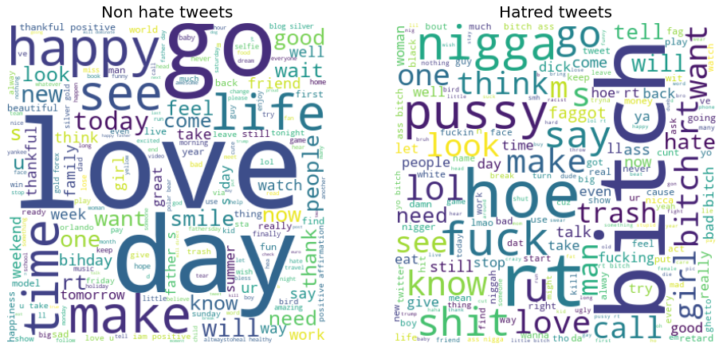

```python
#Most used words

stopwords = STOPWORDS.add('amp')

nonhate_words = ' '.join(tweets[tweets.label == 0].clean_tweet2.values)
hatred_words = ' '.join(tweets[tweets.label == 1].clean_tweet2.values)

plt.figure(figsize=(16, 8))

cloud1 = WordCloud(width=400, height=400, background_color='white', stopwords=stopwords).generate(nonhate_words)
plt.subplot(121)
plt.imshow(cloud1, interpolation="bilinear")
plt.axis("off")
plt.title('Non hate tweets', size=20)

cloud2 = WordCloud(width=400, height=400, background_color='white', stopwords=stopwords).generate(hatred_words)
plt.subplot(122)
plt.imshow(cloud2, interpolation="bilinear")
plt.axis("off")
plt.title('Hatred tweets', size=20)
plt.show()
```

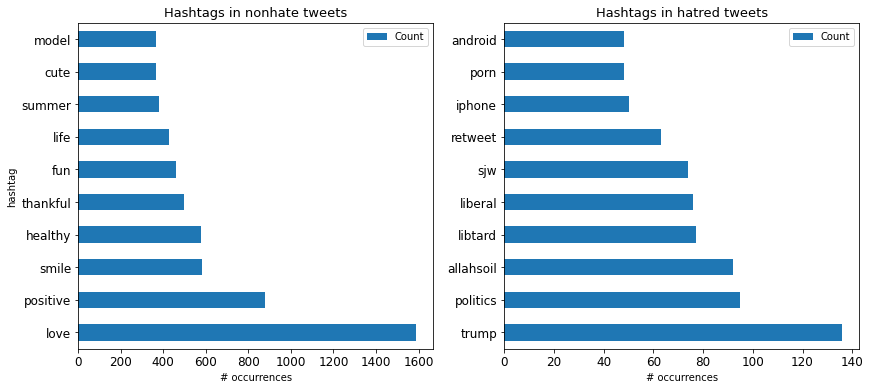

```python
#Most used hashtags

nonhate_hashtags = FreqDist(list(' '.join(tweets[tweets.label==0].hashtags.values).split())).most_common(10)
hatred_hashtags = FreqDist(list(' '.join(tweets[tweets.label==1].hashtags.values).split())).most_common(10)
plt.figure(figsize=(14, 6))
ax = plt.subplot(121)
pd.DataFrame(nonhate_hashtags, columns=['hashtag', 'Count']).set_index('hashtag').plot.barh(ax=ax, fontsize=12)
plt.xlabel('# occurrences')
plt.title('Hashtags in nonhate tweets', size=13)
ax = plt.subplot(122)
pd.DataFrame(hatred_hashtags, columns=['hashtag', 'Count']).set_index('hashtag').plot.barh(ax=ax, fontsize=12)
plt.xlabel('# occurrences')
plt.ylabel('')
plt.title('Hashtags in hatred tweets', size=13)
plt.show()
```

```python
#Splitting the data in 80% train and 20% test

X_train, X_test, Y_train, Y_test = train_test_split(list(tweets.clean_tweet2), list(tweets.label),test_size=0.2, random_state=42)
```

## 6. Pretrained word vectors

### Global Vectors for Word Representation (GloVe)

https://nlp.stanford.edu/projects/glove/

GloVe is an unsupervised learning algorithm developed by researchers at Stanford University aiming to generate word embeddings (vector representations for words). Its training is performed on aggregated global word-word co-occurrence statistics from a corpus, and the resulting representations showcase interesting linear substructures of the word vector space which have the potential for encoding some form of meaning. It's essentially a log-bilinear model with a weighted least-squares objective.

#### Pre-trained GloVe word vectors used:

Twitter (2B tweets, 27B tokens, 1.2M vocab, uncased, 25d, 50d, 100d, & 200d vectors, 1.42 GB download): https://nlp.stanford.edu/data/glove.twitter.27B.zip

```python
#Crating glove dictionary from downloaded pre-trained GloVe word vectors

def get_glove_vectors(filename="glove.twitter.27B.200d.txt"):
    # Get all word vectors from pre-trained model
    glove_vector_dict = {}
    with open(filename) as f:
        for line in f:
            values = line.split()
            word = values[0]
            coefs = values[1:]
            glove_vector_dict[word] = np.asarray(coefs, dtype='float32')

    return glove_vector_dict
```

```python
glove_dict=get_glove_vectors()
```

```python
#Encoding vocabulary from training tweets

tokenizer = Tokenizer()
tokenizer.fit_on_texts(X_train)
```

```python
print(tokenizer.word_index)
```

```
{'be': 1, 'i': 2, 'the': 3, 'a': 4, 'to': 5, 'you': 6, 'bitch': 7, 'not': 8, 'and': 9, 'in': 10, 'rt': 11, 'my': 12, 'of': 13, 'for': 14, 'do': 15, 'that': 16, 'it': 17, 'on': 18, 'get': 19, 'this': 20, 'have': 21, 'with': 22, 'hoe': 23, 'all': 24, 'like': 25, 'love': 26, 'so': 27, 'day': 28, 'they'…
```

```python
#Number of words in our vocabulary

len(tokenizer.word_index)
```

```
38709
```

```python
# Filter GLoVE vectors to our specific vocabulary

def filter_glove(vocabulary_dict, glove_dict, wordvec_dim):
    # Create a matrix to store the vectors
    embedding_matrix = np.zeros((len(vocabulary_dict) + 1, wordvec_dim))
    for word,i in vocabulary_dict.items():
        embedding_vector = glove_dict.get(word)
        if embedding_vector is not None:
            # words not found in the glove_dict will be all-zeros.
            embedding_matrix[i] = embedding_vector
    return embedding_matrix
```

```python
glove_matrix = filter_glove(vocabulary_dict=tokenizer.word_index,glove_dict=glove_dict,wordvec_dim=200)
print(glove_matrix)
```

```
[[ 0.          0.          0.         ...  0.          0.
   0.        ]
 [-0.72794002  0.41955999 -0.28589001 ... -0.1469     -0.035087
  -0.022335  ]
 [ 0.056404    0.49535999  0.18438999 ...  0.63598001 -0.18880001
  -0.035558  ]
 ...
 [ 0.          0.          0.         ...  0.          0.
   0.        ]
 [ 0.          0.          0.         ...  0.          0.
   0.        ]
 [ 0.          0.          0.         ...  0.          0.
   0.        ]]
```

```python
len(glove_matrix)
```

```
38710
```

## 7. Prepare the (X, Y) variables to fit the model

```python
# Change texts into sequence of indexes
train_numeric = tokenizer.texts_to_sequences(X_train)
test_numeric = tokenizer.texts_to_sequences(X_test)
```

```python
for i in range(3):
    print('\n',train_numeric[i],"\n\n",len(train_numeric[i]),"\n\n", X_train[i].split(),"\n\n",len(X_train[i].split()),'\n')
    print("**********************",i)
```

```
 [13, 172, 1, 660, 2223, 121, 13, 863, 114, 57, 23, 1, 145]

 13

 ['of', 'woman', 'be', 'slut', 'freshman', 'year', 'of', 'college', 'let', 'these', 'hoe', 'be', 'great']

 13

********************** 0

 [14598, 14599, 304, 165, 92, 5, 14600, 3, 4161, 14601, 299, 102, 108, 93, 1, 220, 4571, 1076, 10, 3, 1495, 5, 2728, 43]

 24

 ['kip', 'tokuda', 'yellow', 'guy', 'work', 'to', 'niggerize', 'the', 'seattle', 'pd', 'die', 'too', 'bad', 'there', 'be', 'another', 'pos', 'hide', 'in', 'the', 'wing', 'to', 'replace', 'he']

 24

********************** 1

 [421, 40, 1, 14602, 14603]

 5

 ['laugh', 'amp', 'be', 'positip', 'plusfactorph']

 5

********************** 2
```

```python
# Largest tweet

largest=0
for i in range(len(train_numeric)):
    largest=max(largest,len(train_numeric[i]))
for i in range(len(test_numeric)):
    largest=max(largest,len(test_numeric[i]))

print(largest)
```

```
37
```

```python
# Pad the sequences
train_pad = pad_sequences(train_numeric, largest)
test_pad = pad_sequences(test_numeric, largest)
Y_train = numpy.array(Y_train)
Y_test = numpy.array(Y_test)
```

```python
for i in range(3):
    print('\n',train_pad[i],"\n\n",len(train_pad[i]),"\n\n", X_train[i].split(),"\n\n",len(X_train[i].split()),'\n')
    print("**********************",i)
```

```
 [   0    0    0    0    0    0    0    0    0    0    0    0    0    0
    0    0    0    0    0    0    0    0    0    0   13  172    1  660
 2223  121   13  863  114   57   23    1  145]

 37

 ['of', 'woman', 'be', 'slut', 'freshman', 'year', 'of', 'college', 'let', 'these', 'hoe', 'be', 'great']

 13

********************** 0

 [    0     0     0     0     0     0     0     0     0     0     0     0
     0 14598 14599   304   165    92     5 14600     3  4161 14601   299
   102   108    93     1   220  4571  1076    10     3  1495     5  2728
    43]

 37

 ['kip', 'tokuda', 'yellow', 'guy', 'work', 'to', 'niggerize', 'the', 'seattle', 'pd', 'die', 'too', 'bad', 'there', 'be', 'another', 'pos', 'hide', 'in', 'the', 'wing', 'to', 'replace', 'he']

 24

********************** 1

 [    0     0     0     0     0     0     0     0     0     0     0     0
     0     0     0     0     0     0     0     0     0     0     0     0
     0     0     0     0     0     0     0     0   421    40     1 14602
 14603]

 37

 ['laugh', 'amp', 'be', 'positip', 'plusfactorph']

 5

********************** 2
```

## 8. Creating the model using keras

In the model different layers are applied such as Dropout, LSTM and Gru to account for the issues that might arise when implementing a RNN model.

- Both LSTM and GRU layers are used to account for "Exploding Gradient" and "Vanishing Gradient" issues.
- Dropout is used "to prevent over-fitting" by ignoring units (i.e. neurons) during the training phase of certain set of neurons which is chosen at random.
- Also, pre-trained weights are used in this model by passing Glove to the Embedding layer. This improves much more the performance since it gives information to the model about the probability for most of the words to appear in the tweets.

### Basic RNN model with LSTM, GRU and Dropout layers

```python
# Instantiate the model class
model_basic = Sequential()

# Add the layers
model_basic.add(Embedding(input_dim=len(tokenizer.word_index)+1,
                    output_dim=200,
                    trainable=False,
                    input_length=largest, name="Embedding"))
model_basic.add(Dense(200,activation='relu', name="Dense1"))
model_basic.add(Dropout(rate=0.25))
model_basic.add(LSTM(64, return_sequences=True, dropout=0.15, name="LSTM"))
model_basic.add(GRU(64, return_sequences=False, dropout=0.15, name="GRU"))
model_basic.add(Dense(64, name="Dense2"))
model_basic.add(Dropout(rate=0.25))
model_basic.add(Dense(32, name="Dense3"))
model_basic.add(Dense(1, activation='sigmoid', name="Output"))

model_basic.compile(optimizer='adam', loss='binary_crossentropy', metrics=['accuracy'])

history = model_basic.fit(train_pad,Y_train, epochs=10, validation_data=(test_pad,Y_test), batch_size=32)
```

```python
model_basic.summary()
```

```
Model: "sequential_27"
_________________________________________________________________
 Layer (type)                Output Shape              Param #
=================================================================
 Embedding (Embedding)       (None, 37, 200)           7742000

 Dense1 (Dense)              (None, 37, 200)           40200

 dropout_54 (Dropout)        (None, 37, 200)           0

 LSTM (LSTM)                 (None, 37, 64)            67840

 GRU (GRU)                   (None, 64)                24960

 Dense2 (Dense)              (None, 64)                4160

 dropout_55 (Dropout)        (None, 64)                0

 Dense3 (Dense)              (None, 32)                2080

 Output (Dense)              (None, 1)                 33

=================================================================
Total params: 7,881,273
Trainable params: 139,273
Non-trainable params: 7,742,000
_________________________________________________________________
```

```python
print('Loss:',round(np.mean(history.history['val_loss']),4),'Accuracy:',round(100*np.mean(history.history['val_accuracy']),2),'%')
```

```
Loss: 0.1668 Accuracy: 93.81 %
```

### Adding Glove pretrained word vectors to the model

```python
# Instantiate the model class
model_GloVe = Sequential()

# Add the layers
model_GloVe.add(Embedding(input_dim=len(tokenizer.word_index)+1,
                    output_dim=200,
                    trainable=False,
                    embeddings_initializer=Constant(glove_matrix),
                    input_length=largest, name="Embedding"))
model_GloVe.add(Dense(200,activation='relu', name="Dense1"))
model_GloVe.add(Dropout(rate=0.25))
model_GloVe.add(LSTM(64, return_sequences=True, dropout=0.15, name="LSTM"))
model_GloVe.add(GRU(64, return_sequences=False, dropout=0.15, name="GRU"))
model_GloVe.add(Dense(64, name="Dense2"))
model_GloVe.add(Dropout(rate=0.25))
model_GloVe.add(Dense(32, name="Dense3"))
model_GloVe.add(Dense(1, activation='sigmoid', name="Output"))

model_GloVe.compile(optimizer='adam', loss='binary_crossentropy', metrics=['accuracy'])

history = model_GloVe.fit(train_pad,Y_train, epochs=10, validation_data=(test_pad,Y_test), batch_size=32)
```

```python
print('Loss:',round(np.mean(history.history['val_loss']),4),'Accuracy:',round(100*np.mean(history.history['val_accuracy']),2),'%')
```

```
Loss: 0.1536 Accuracy: 94.24 %
```

## 9. Evaluating the model with different parameters and CNN layer

List of paramaters which are optimized:

- Batch size of the model - it pertains to the amount of training samples to consider at a time for updating the network weights
- The dropout rate - fraction of the input units to drop, used to add noise to the model
- Trainable argument of the Embedding layer - false for keeping the weights fixed and True if the weights will be updated during the training
- Adding Conv1D layer from Convolutional Neural Network - creates a convolution kernel that is convolved with the layer input over a single spatial (or temporal) dimension to produce a tensor of outputs

### Parameters tuning

```python
# epochs: determine how many weight updates will be done on the model -> We choose 20
# batch_size: size of the data on each step -> Also increases the speed of the training, depends on the computer capacity
# drop: rate of the dropout layer, used to add noise to the model

model_list = []
for drop in [0, 0.1, 0.2, 0.3, 0.4]:
    for batch in [16, 32, 64, 80]:
        seed(321)
        tensorflow.random.set_seed(123)

        model = Sequential()

        # Add the layers
        model.add(Embedding(input_dim=len(tokenizer.word_index)+1,
                            output_dim=200,
                            trainable=False,
                            embeddings_initializer=Constant(glove_matrix),
                            input_length=largest, name="Embedding"))
        model.add(Dense(200,activation='relu', name="Dense1"))
        model.add(Dropout(drop))
        model.add(LSTM(64, return_sequences=True, dropout=drop, name="LSTM"))
        model.add(GRU(64, return_sequences=False, dropout=drop, name="GRU"))
        model.add(Dense(64, name="Dense2"))
        model.add(Dropout(drop))
        model.add(Dense(32, name="Dense3"))
        model.add(Dense(1, activation='sigmoid', name="Output"))


        model.compile(optimizer='adam', loss='binary_crossentropy', metrics=['accuracy'])

        print(drop,batch)

        history = model.fit(train_pad,Y_train, epochs=10, validation_data=(test_pad,Y_test), batch_size=batch)
        model_list.append([drop, batch, np.mean(history.history['val_loss']),np.mean(history.history['val_accuracy'])])
```

```
0 16
0 32
0 64
0 80
0.1 16
0.1 32
0.1 64
0.1 80
0.2 16
0.2 32
0.2 64
0.2 80
0.3 16
0.3 32
0.3 64
0.3 80
0.4 16
0.4 32
0.4 64
0.4 80
```

```python
df_models = pd.DataFrame(model_list, columns = ['dropout', 'batch', 'loss', 'accuracy'])
```

```python
df_models.sort_values('loss').head()
```

|  | dropout | batch | loss | accuracy |
| --- | --- | --- | --- | --- |
| 12 | 0.3 | 16 | 0.153357 | 0.941264 |
| 13 | 0.3 | 32 | 0.153782 | 0.942083 |
| 9 | 0.2 | 32 | 0.154403 | 0.942955 |
| 11 | 0.2 | 80 | 0.155375 | 0.941219 |
| 14 | 0.3 | 64 | 0.155473 | 0.940876 |

```python
df_models.sort_values('accuracy',ascending=False).head()
```

|  | dropout | batch | loss | accuracy |
| --- | --- | --- | --- | --- |
| 9 | 0.2 | 32 | 0.154403 | 0.942955 |
| 8 | 0.2 | 16 | 0.157396 | 0.942594 |
| 13 | 0.3 | 32 | 0.153782 | 0.942083 |
| 5 | 0.1 | 32 | 0.164965 | 0.941775 |
| 4 | 0.1 | 16 | 0.163177 | 0.941510 |

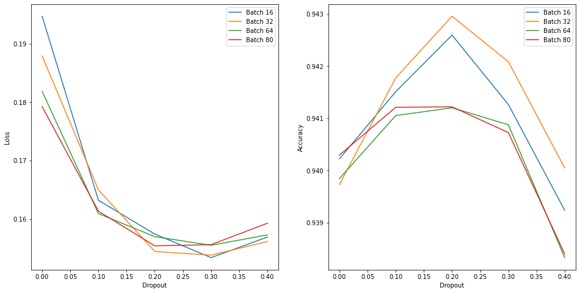

```python
plt.figure(figsize=(16, 8))

plt.subplot(1, 2, 1)
plt.plot(df_models[df_models['batch']==16]['dropout'],df_models[df_models['batch']==16]['loss'])
plt.plot(df_models[df_models['batch']==32]['dropout'],df_models[df_models['batch']==32]['loss'])
plt.plot(df_models[df_models['batch']==64]['dropout'],df_models[df_models['batch']==64]['loss'])
plt.plot(df_models[df_models['batch']==80]['dropout'],df_models[df_models['batch']==80]['loss'])
plt.xlabel("Dropout")
plt.ylabel('Loss')
plt.legend(['Batch 16', 'Batch 32', 'Batch 64', 'Batch 80'])

plt.subplot(1, 2, 2)
plt.plot(df_models[df_models['batch']==16]['dropout'],df_models[df_models['batch']==16]['accuracy'])
plt.plot(df_models[df_models['batch']==32]['dropout'],df_models[df_models['batch']==32]['accuracy'])
plt.plot(df_models[df_models['batch']==64]['dropout'],df_models[df_models['batch']==64]['accuracy'])
plt.plot(df_models[df_models['batch']==80]['dropout'],df_models[df_models['batch']==80]['accuracy'])
plt.xlabel("Dropout")
plt.ylabel('Accuracy')
plt.legend(['Batch 16', 'Batch 32', 'Batch 64', 'Batch 80'])
```

The highest accuracy is achieved with drop=0.2 and batch_size=32, so this will be our chosen parameters for the model.

### Chosen parameters model

```python
# Instantiate the model class
model = Sequential()

# Add the layers
model.add(Embedding(input_dim=len(tokenizer.word_index)+1,
                    output_dim=200,
                    trainable=False,
                    embeddings_initializer=Constant(glove_matrix),
                    input_length=largest, name="Embedding"))
model.add(Dense(200,activation='relu', name="Dense1"))
model.add(Dropout(rate=0.2))
model.add(LSTM(64, return_sequences=True, dropout=0.2, name="LSTM"))
model.add(GRU(64, return_sequences=False, dropout=0.2, name="GRU"))
model.add(Dense(64, name="Dense2"))
model.add(Dropout(rate=0.2))
model.add(Dense(32, name="Dense3"))
model.add(Dense(1, activation='sigmoid', name="Output"))

model.compile(optimizer='adam', loss='binary_crossentropy', metrics=['accuracy'])
```

```python
history = model.fit(train_pad,Y_train,
                       epochs=10,
                       validation_data=(test_pad,Y_test),
                       batch_size=32)
```

```python
def plot_graphs(history, metric):
    plt.plot(history.history[metric])
    plt.plot(history.history['val_'+metric], '')
    plt.xlabel("Epochs")
    plt.ylabel(metric)
    plt.legend(['train_'+metric, 'test_'+metric])
```

```
(0.0, 0.2088667292147875)
```

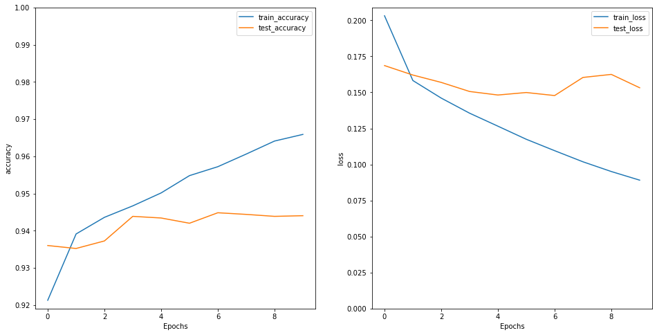

```python
plt.figure(figsize=(16, 8))
plt.subplot(1, 2, 1)
plot_graphs(history, 'accuracy')
plt.ylim(None, 1)
plt.subplot(1, 2, 2)
plot_graphs(history, 'loss')
plt.ylim(0, None)
```

```python
#Evaluate the model:
score_train, acc_train = model.evaluate(train_pad, Y_train)
score_test, acc_test = model.evaluate(test_pad, Y_test)
print('Train:\n Loss:',round(score_train,4),'Acc:',round(acc_train*100,2),'% ')
print('Test:\n Loss:',round(score_test,4),'Acc:',round(acc_test*100,2),'% ')
```

```
Train:
 Loss: 0.0583 Acc: 98.03 %
Test:
 Loss: 0.1532 Acc: 94.4 %
```

### Trainable Embedding layer

```python
# Instantiate the model class
model_trainable = Sequential()

# Add the layers
model_trainable.add(Embedding(input_dim=len(tokenizer.word_index)+1,
                    output_dim=200,
                    trainable=True,
                    embeddings_initializer=Constant(glove_matrix),
                    input_length=largest, name="Embedding"))
model_trainable.add(Dense(200,activation='relu', name="Dense1"))
model_trainable.add(Dropout(rate=0.2))
model_trainable.add(LSTM(64, return_sequences=True, dropout=0.2, name="LSTM"))
model_trainable.add(GRU(64, return_sequences=False, dropout=0.2, name="GRU"))
model_trainable.add(Dense(64, name="Dense2"))
model_trainable.add(Dropout(rate=0.2))
model_trainable.add(Dense(32, name="Dense3"))
model_trainable.add(Dense(1, activation='sigmoid', name="Output"))

model_trainable.compile(optimizer='adam', loss='binary_crossentropy', metrics=['accuracy'])

model_trainable.summary()
```

```
Model: "sequential_49"
_________________________________________________________________
 Layer (type)                Output Shape              Param #
=================================================================
 Embedding (Embedding)       (None, 37, 200)           7742000

 Dense1 (Dense)              (None, 37, 200)           40200

 dropout_98 (Dropout)        (None, 37, 200)           0

 LSTM (LSTM)                 (None, 37, 64)            67840

 GRU (GRU)                   (None, 64)                24960

 Dense2 (Dense)              (None, 64)                4160

 dropout_99 (Dropout)        (None, 64)                0

 Dense3 (Dense)              (None, 32)                2080

 Output (Dense)              (None, 1)                 33

=================================================================
Total params: 7,881,273
Trainable params: 7,881,273
Non-trainable params: 0
_________________________________________________________________
```

```python
history = model_trainable.fit(train_pad,Y_train,
                              epochs=10,
                              validation_data=(test_pad,Y_test),
                              batch_size=32)
```

```
(0.0, 0.4359291675500572)
```

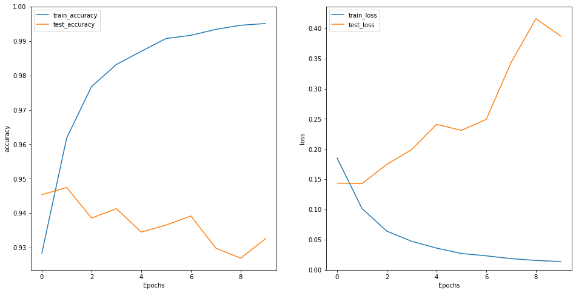

```python
plt.figure(figsize=(16, 8))
plt.subplot(1, 2, 1)
plot_graphs(history, 'accuracy')
plt.ylim(None, 1)
plt.subplot(1, 2, 2)
plot_graphs(history, 'loss')
plt.ylim(0, None)
```

```python
#Evaluate the model:
score_train_trainable, acc_train_trainable = model_trainable.evaluate(train_pad, Y_train)
score_test_trainable, acc_test_trainable = model_trainable.evaluate(test_pad, Y_test)
print('Train:\n Loss:',round(score_train_trainable,4),'Acc:',round(acc_train_trainable*100,2),'% ')
print('Test:\n Loss:',round(score_test_trainable,4),'Acc:',round(acc_test_trainable*100,2),'% ')
```

```
Train:
 Loss: 0.007 Acc: 99.79 %
Test:
 Loss: 0.3871 Acc: 93.26 %
```

It improved the performance for the training dataset, but it got worse for the test one. This seems logic since training more parameters we got to make the model more specific,i.e., we trained it to make better predictions on tweets more similar to the ones we used for training it. It makes the model less general, and worse predicting new and more different tweets. It is something similar to what happens when reducing the drop_out rate.

Therefore, we stablish the trainable argument = False.

### Convolution layer

The mix of convolution and max pooling layers with RNN cells has been used recently and achieved state of the art results in NLP problems. In short:

- The Conv1D has filters that determines the output dimension, kernel size which is the window size for convolution and padding which determines if the input should be padded (add zeros around the matrix) or not.
- The MaxPooling1D contains the parameter pool size that determines the window to look for the max value.

```python
# Instantiate the model class
modelcnn = Sequential()

# Add the layers
modelcnn.add(Embedding(input_dim=len(tokenizer.word_index)+1,
                    output_dim=200,
                    trainable=False,
                    embeddings_initializer=Constant(glove_matrix),
                    input_length=largest, name="Embedding"))
modelcnn.add(Conv1D(filters=32, kernel_size=3, padding='same'))
modelcnn.add(MaxPooling1D(pool_size=2))
modelcnn.add(Dense(200,activation='relu', name="Dense1"))
modelcnn.add(Dropout(rate=0.2))
modelcnn.add(LSTM(64, return_sequences=True, dropout=0.2, name="LSTM"))
modelcnn.add(GRU(64, return_sequences=False, dropout=0.2, name="GRU"))
modelcnn.add(Dense(64, name="Dense2"))
modelcnn.add(Dropout(rate=0.2))
modelcnn.add(Dense(32, name="Dense3"))
modelcnn.add(Dense(1, activation='sigmoid', name="Output"))

modelcnn.compile(optimizer='adam', loss='binary_crossentropy', metrics=['accuracy'])

modelcnn.summary()
```

```
Model: "sequential_50"
_________________________________________________________________
 Layer (type)                Output Shape              Param #
=================================================================
 Embedding (Embedding)       (None, 37, 200)           7742000

 conv1d (Conv1D)             (None, 37, 32)            19232

 max_pooling1d (MaxPooling1D  (None, 18, 32)           0
 )

 Dense1 (Dense)              (None, 18, 200)           6600

 dropout_100 (Dropout)       (None, 18, 200)           0

 LSTM (LSTM)                 (None, 18, 64)            67840

 GRU (GRU)                   (None, 64)                24960

 Dense2 (Dense)              (None, 64)                4160

 dropout_101 (Dropout)       (None, 64)                0

 Dense3 (Dense)              (None, 32)                2080

 Output (Dense)              (None, 1)                 33

=================================================================
Total params: 7,866,905
Trainable params: 124,905
Non-trainable params: 7,742,000
_________________________________________________________________
```

```python
history = modelcnn.fit(train_pad,Y_train,
                       epochs=10,
                       validation_data=(test_pad,Y_test),
                       batch_size=32)
```

```
(0.0, 0.2222105573862791)
```

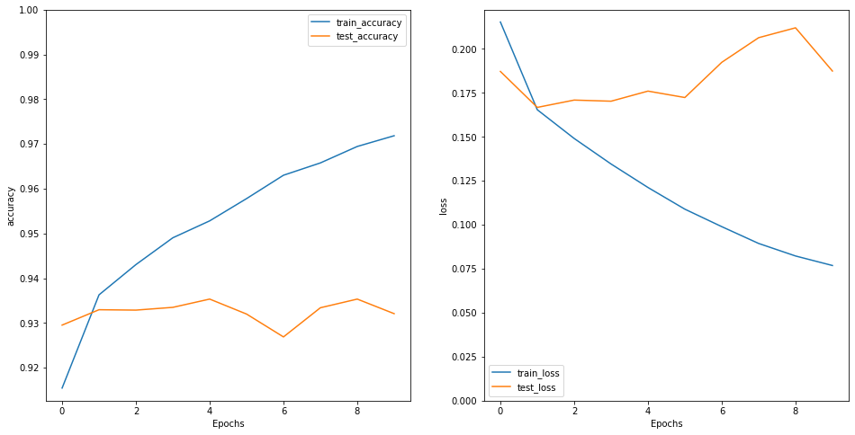

```python
plt.figure(figsize=(16, 8))
plt.subplot(1, 2, 1)
plot_graphs(history, 'accuracy')
plt.ylim(None, 1)
plt.subplot(1, 2, 2)
plot_graphs(history, 'loss')
plt.ylim(0, None)
```

```python
#Evaluate the model:
score_train_cnn, acc_train_cnn = modelcnn.evaluate(train_pad, Y_train)
score_test_cnn, acc_test_cnn = modelcnn.evaluate(test_pad, Y_test)
print('Train:\n Loss:',round(score_train_cnn,4),'% ','Acc:',round(acc_train_cnn*100,2),'% ')
print('Test:\n Loss:',round(score_test_cnn,4),'% ','Acc:',round(acc_test_cnn*100,2),'% ')
```

```
Train:
 Loss: 0.053 %  Acc: 98.41 %
Test:
 Loss: 0.1874 %  Acc: 93.21 %
```

In a similar way like the trainable embedding layer, the convolution layers improved a litte the performance of the model for the training dataset, but it got worse for the test one. The test loss increases with the trainings and the accuracy seems to lightly decrease.

Therefore, we decide to reject the idea of adding CNN layers to the model.

## 10. Evaluating the predictions for the final model

```python
#Results of the previous evaluation of the final model:
print('Train:\n Loss:',round(score_train,4),'Acc:',round(acc_train*100,2),'% ')
print('Test:\n Loss:',round(score_test,4),'Acc:',round(acc_test*100,2),'% ')
```

```
Train:
 Loss: 0.0583 Acc: 98.03 %
Test:
 Loss: 0.1532 Acc: 94.4 %
```

```python
#Predictions on the training data (apparently not 100% acc)

pred_train=model.predict(train_pad)
print(pred_train)
```

```
[[9.9955750e-01]
 [7.0508212e-01]
 [2.6620869e-04]
 ...
 [9.5287555e-01]
 [9.4177298e-02]
 [9.9914247e-01]]
```

```python
for i in range(len(pred_train)):
    if pred_train[i]<0.5:
        pred_train[i]=0
    else:
        pred_train[i]=1
```

```python
print("TRAIN:\n\nHatred labeled: {}\nNon-hatred labeled: {}\nTotal number of tweets: {}".format(
    (Y_train == 1).sum(),
    (Y_train == 0).sum(),
    len(Y_train)
))
print()
print("PREDICTED TRAIN:\n\nHatred labeled: {}\nNon-hatred labeled: {}\nTotal number of tweets: {}".format(
    (pred_train == 1).sum(),
    (pred_train == 0).sum(),
    len(pred_train)
))
cf_matrix = confusion_matrix(Y_train, pred_train)
print('\nConfusion matrix:\n\n',cf_matrix)
```

```
TRAIN:

Hatred labeled: 19276
Non-hatred labeled: 26120
Total number of tweets: 45396

PREDICTED TRAIN:

Hatred labeled: 19027
Non-hatred labeled: 26369
Total number of tweets: 45396

Confusion matrix:

 [[25797   323]
 [  572 18704]]
```

```python
#Predictions on the test data

pred_test=model.predict(test_pad)
```

```python
for i in range(len(pred_test)):
    if pred_test[i]<0.5:
        pred_test[i]=0
    else:
        pred_test[i]=1
```

```python
print("TEST:\n\nHatred labeled: {}\nNon-hatred labeled: {}\nTotal number of tweets: {}".format(
    (Y_test == 1).sum(),
    (Y_test == 0).sum(),
    len(Y_test)
))
print()
print("PREDICTED TEST:\n\nHatred labeled: {}\nNon-hatred labeled: {}\nTotal number of tweets: {}".format(
    (pred_test == 1).sum(),
    (pred_test == 0).sum(),
    len(pred_test)
))
cf_matrix = confusion_matrix(Y_test, pred_test)
print('\nConfusion matrix:\n\n',cf_matrix)
```

```
TEST:

Hatred labeled: 4877
Non-hatred labeled: 6472
Total number of tweets: 11349

PREDICTED TEST:

Hatred labeled: 4746
Non-hatred labeled: 6603
Total number of tweets: 11349

Confusion matrix:

 [[6220  252]
 [ 383 4494]]
```

### Evaluating on original project data

```python
# Cleaning tweets
original_data= pd.read_csv('train_original.csv')
hashtags = original_data['tweet'].str.extractall('#(?P<hashtag>[a-zA-Z0-9_]+)').reset_index().groupby('level_0').agg(lambda x: ' '.join(x.values))
original_data.loc[:, 'hashtags'] = hashtags['hashtag']
original_data['hashtags'].fillna('', inplace=True)
original_data['clean_tweet'] = original_data['tweet'].apply(lambda x: re.sub(r'http\S+', '', x))
original_data['clean_tweet'] = original_data['clean_tweet'].apply(lambda x: re.sub('@[a-zA-Z0-9_]+', '', x))
original_data['clean_tweet'] = original_data['clean_tweet'].apply(lambda x: ''.join(ch for ch in x if ch not in set(punctuation)))
original_data['clean_tweet'] = original_data['clean_tweet'].str.lower()
original_data['clean_tweet'] = original_data['clean_tweet'].str.replace("[0-9]", " ")
original_data['clean_tweet'] = original_data['clean_tweet'].apply(lambda x:' '.join(x.split()))
original_data['clean_tweet'] = lemmatization(original_data['clean_tweet'])
original_data['clean_tweet'] = original_data.clean_tweet.str.replace('[^a-zA-Z]', ' ')
```

```python
original_data_numeric = tokenizer.texts_to_sequences(original_data.clean_tweet)
original_data_pad = pad_sequences(original_data_numeric, largest)
pred_od=model.predict(original_data_pad)
```

```python
for i in range(len(pred_od)):
    if pred_od[i]<0.5:
        pred_od[i]=0
    else:
        pred_od[i]=1
```

```python
print("TRAIN:\n\nHatred labeled: {}\nNon-hatred labeled: {}\nTotal number of tweets: {}".format(
    (original_data['label'] == 1).sum(),
    (original_data['label'] == 0).sum(),
    len(original_data)
))
print()
print("PREDICTED TRAIN:\n\nHatred labeled: {}\nNon-hatred labeled: {}\nTotal number of tweets: {}".format(
    (pred_od == 1).sum(),
    (pred_od == 0).sum(),
    len(pred_od)
))
cf_matrix = confusion_matrix(original_data['label'], pred_od)
print('\nConfusion matrix:\n\n',cf_matrix)
```

```
TRAIN:

Hatred labeled: 2242
Non-hatred labeled: 29720
Total number of tweets: 31962

PREDICTED TRAIN:

Hatred labeled: 2179
Non-hatred labeled: 29783
Total number of tweets: 31962

Confusion matrix:

 [[29406   314]
 [  377  1865]]
```

```python
#Evaluate the model:
score_od, acc_od = model.evaluate(original_data_pad, original_data['label'])
print('Original data test:\n Loss:',round(score_od,4),'Acc:',round(acc_od*100,2),'% ')
```

```
Original data test:
 Loss: 0.0684 Acc: 97.84 %
```

## 11. Making predictions on new data

```python
# Cleaning tweets
new_data= pd.read_csv('test.csv')
hashtags = new_data['tweet'].str.extractall('#(?P<hashtag>[a-zA-Z0-9_]+)').reset_index().groupby('level_0').agg(lambda x: ' '.join(x.values))
new_data.loc[:, 'hashtags'] = hashtags['hashtag']
new_data['hashtags'].fillna('', inplace=True)
new_data['clean_tweet'] = new_data['tweet'].apply(lambda x: re.sub(r'http\S+', '', x))
new_data['clean_tweet'] = new_data['clean_tweet'].apply(lambda x: re.sub('@[a-zA-Z0-9_]+', '', x))
new_data['clean_tweet'] = new_data['clean_tweet'].apply(lambda x: ''.join(ch for ch in x if ch not in set(punctuation)))
new_data['clean_tweet'] = new_data['clean_tweet'].str.lower()
new_data['clean_tweet'] = new_data['clean_tweet'].str.replace("[0-9]", " ")
new_data['clean_tweet'] = new_data['clean_tweet'].apply(lambda x:' '.join(x.split()))
new_data['clean_tweet'] = lemmatization(new_data['clean_tweet'])
new_data['clean_tweet'] = new_data.clean_tweet.str.replace('[^a-zA-Z]', ' ')
new_data.head(8)
```

|  | id | tweet | hashtags | clean_tweet |
| --- | --- | --- | --- | --- |
| 0 | 31963 | #studiolife #aislife #requires #passion #dedication #willpower to find #newmaterialsâ¦ | studiolife aislife requires passion dedication willpower newmaterials | studiolife aislife require passion dedication willpower to find newmaterials |
| 1 | 31964 | @user #white #supremacists want everyone to see the new â #birdsâ #movie â and hereâs why | white supremacists birds movie | white supremacist want everyone to see the new birds movie and here s why |
| 2 | 31965 | safe ways to heal your #acne!! #altwaystoheal #healthy #healing!! | acne altwaystoheal healthy healing | safe way to heal your acne altwaystoheal healthy healing |
| 3 | 31966 | is the hp and the cursed child book up for reservations already? if yes, where? if no, when? ððð #harrypotter #pottermore #favorite | harrypotter pottermore favorite | be the hp and the cursed child book up for reservation already if yes where if no when harrypotter pottermore favorite |
| 4 | 31967 | 3rd #bihday to my amazing, hilarious #nephew eli ahmir! uncle dave loves you and missesâ¦ | bihday nephew | rd bihday to my amazing hilarious nephew eli ahmir uncle dave love you and misses |
| 5 | 31968 | choose to be :) #momtips | momtips | choose to be momtip |
| 6 | 31969 | something inside me dies ð¦ð¿â¨ eyes ness #smokeyeyes #tired #lonely #sof #grungeâ¦ | smokeyeyes tired lonely sof grunge | something inside I die eye ness smokeyeye tired lonely sof grunge |
| 7 | 31970 | #finished#tattoo#inked#ink#loveitâ¤ï¸ #â¤ï¸â¤ï¸â¤ï¸â¤ï¸ #thanks#aleeee !!! | finished tattoo inked ink loveit thanks aleeee | finishedtattooinkedinkloveit thanksaleeee |

```python
newdata_numeric = tokenizer.texts_to_sequences(new_data.clean_tweet)
newdata_pad = pad_sequences(newdata_numeric, largest)
pred_nd=model.predict(newdata_pad)
```

```python
new_data['label_predicted']=0

for i in range(len(pred_nd)):
    if pred_nd[i]<0.5:
        new_data['label_predicted'][i]=0
    else:
        new_data['label_predicted'][i]=1
```

```python
#pd.set_option('display.max_colwidth', None)
new_data[new_data.label_predicted == 1][['tweet','label_predicted']].sample(10)
```

|  | tweet | label_predicted |
| --- | --- | --- |
| 5612 | #rapeculture at its finest! i'm so that this comment is on my newsfeed. and from a news agency. how? | 1 |
| 17192 | thought factory: left-right polarisation! #trump #uselections2016 #leadership #politics #brexit #blm &gt;3 | 1 |
| 16195 | @user #feminismiscancer #feminismisterrorism #feminismmuktbharat why #malevote is ignored @user | 1 |
| 8346 | @user nope not factual. your comments are reflections of ignorance and @user | 1 |
| 14625 | @user some privileged white people just sat in a tim hoons without perchasing anything. and we walked in and took our cab. #â¦ | 1 |
| 10804 | @user @user @user #trump #trumpster #hateful #intolerant #bigots obnoxious violent #divisive @user #truth | 1 |
| 10071 | "nigger?" #lifelessons of a white kid who grew up in the 60's. #blogpost #whitepeople #respectâ¦ | 1 |
| 2733 | if pisses you off like it pisses me off, here's something you oughta know... this guy's a racist creep.â¦ | 1 |
| 1670 | still the most proud of this one. #misogyny #culturalstandards #women #makeup #beautystandards #exhaustionâ¦ | 1 |
| 2520 | #sikh #temple vandalised in in #calgary, #wso condemns act | 1 |

```python
new_data[['tweet','label_predicted']].sample(10)
```

|  | tweet | label_predicted |
| --- | --- | --- |
| 12825 | praying this all works out but everything in life is slowly coming together #blessed | 0 |
| 1518 | the ð in disguise. #family #niece #love #family #alain #dubai #mydubai #dxb #angelsâ¦ | 0 |
| 13652 | ð #love #instagood #photooftheday @user #tbt #cute #me #beautiful #followme #follow #fashion #selfie #picoftheday #like4like | 0 |
| 10034 | be n #healthy never be afraid to sit a while and think. â lorraine hansberry | 0 |
| 11621 | 100 amazing health benefits of cucumbers! #healthy is !! #altwaystoheal! | 0 |
| 13762 | current mood. have a great thursday! #justbehappy #behappy #blogger #propey #homes #thursday thursday | 0 |
| 16938 | i am abundant.#i_am #positive #affirmation | 0 |
| 11318 | @user after having the first gen pebble, and the apple watch, i can gladly say i'm back with pebble time #pebbletime @user | 0 |
| 12008 | selfie pa more âððð #saturday #selfie #simple #selca #photogrid #smile | 0 |
| 16992 | the dog campaign i shared for a friend &amp; the dog she adopted is no longer needed. the dog passed today, 2 days after being rescued. | 0 |

```python
print("Hatred labeled: {}\nNon-hatred labeled: {}\nTotal number of tweets: {}".format(
    (new_data.label_predicted == 1).sum(),
    (new_data.label_predicted == 0).sum(),
    len(new_data)
))
```

```
Hatred labeled: 1184
Non-hatred labeled: 16013
Total number of tweets: 17197
```

In the last step, we are running our trained model on the test dataset used in the original project which had non labeled tweets. What is important to note about this test dataset is that the tweets were collected during the #TrumpImpeachment and the #BlackLivesMatter movement.

We notice that the model predicts correctly as hateful tweets the ones containing words indicating racism, sexism, misoginy and political polarization. This is an indication that our model performs well, even in a new and not related dataset.

## 12. Conclusion

The best model performance was shown by the RNN model with LSTM, GRU, Dropout and GloVe Embedding layers.

The parameters with the best results where batch_size=32 and Drop_out=0.2.

Training the Embedding layer parameters or adding CNN layers to the model did improve the results for the train data , but did not for the test data, we need a more general model which predicts more diverse tweets. That is why the final model was the one chosen without Training Embedding layer and without CNN layers. This is exactly the same behavior that we observed in the original project, which is a further indicator that our model was properly built.

The final model achieved an Accuracy value of 94.4% and a Loss value of 0.1532. This is a pretty good result, but comparing it to the original project (Acc:96.21%, Loss:0.1359) it is slightly lower, even though we are using almost the double amount of tweets. However testing our new model on the original project's dataset we achieve an Accuracy value of 97.84% and Loss value of 0.0684, a better result that could be explained by the fact that our model was trained in a more diverse and larger amount of tweets.

The predictions made on the unlabeled test data from the original project are also a good indicator that our model was properly build and is performing quite good, it guesses tweets which are hate spreaders very well.